# Data example 7: LMM and GLMM

## 1. Example 1 for LMM: Smoking prevention and cessation study

1600 students are collected from 135 classrooms in 28 schools. We want to understand the effect of SC (exposure to a school-based curriculum or not), TV (exposure to a television-based prevention program or not) and previous THK scale on the current THK scale. We have $1600$ samples, but some share the same school and some share the same classroom.

The multilevel model:
$$y_{ics} = \beta_0 + \beta_1\text{PTHK}_{ics} + \beta_2\text{SC}_{ics} + \beta_3\text{TV}_{ics} + u_s + v_{cs} + \epsilon_{ics}$$

```r
Smoking <- read.table("Smoking.dat", header = T)
Smoking
```

| school | class | SC | TV | PTHK | y |
| --- | --- | --- | --- | --- | --- |
| 403 | 403101 | 1 | 0 | 2 | 3 |
| 403 | 403101 | 1 | 0 | 4 | 4 |
| 403 | 403101 | 1 | 0 | 4 | 3 |
| 403 | 403101 | 1 | 0 | 3 | 4 |
| 403 | 403101 | 1 | 0 | 3 | 4 |
| 403 | 403101 | 1 | 0 | 4 | 3 |
| 403 | 403101 | 1 | 0 | 2 | 2 |
| 403 | 403101 | 1 | 0 | 4 | 4 |
| 403 | 403101 | 1 | 0 | 5 | 5 |
| 403 | 403101 | 1 | 0 | 3 | 4 |

[output cut: 1590 more lines]

The LMM can be solved using R package lme4

```r
library(lme4)
fit <- lmer(y ~ PTHK + SC + TV + (1|school) + (1|class), data = Smoking) # Fitting the variances is by REML
summary(fit)
```

```
## Linear mixed model fit by REML ['lmerMod']
## Formula: y ~ PTHK + SC + TV + (1 | school) + (1 | class)
##    Data: Smoking
##
## REML criterion at convergence: 5374.3
##
## Scaled residuals:
##     Min      1Q  Median      3Q     Max
## -2.5202 -0.6975 -0.0177  0.6875  3.1630
##
## Random effects:
##  Groups   Name        Variance Std.Dev.
##  class    (Intercept) 0.06853  0.2618
##  school   (Intercept) 0.03925  0.1981
##  Residual             1.60108  1.2653
## Number of obs: 1600, groups:  class, 135; school, 28
##
## Fixed effects:
##             Estimate Std. Error t value
## (Intercept)  1.78493    0.11295  15.803
## PTHK         0.30524    0.02590  11.786
## SC           0.47147    0.11330   4.161
## TV           0.01956    0.11330   0.173
##
## Correlation of Fixed Effects:
##      (Intr) PTHK   SC
## PTHK -0.493
## SC   -0.503  0.025
## TV   -0.521  0.015 -0.002
```

- The random effects are small compared to the noise, but as you will see later it can still substantially increase the variance of $\hat\beta$.
- Testing for the variance of the random effect terms is complicated. A standard likelihood ratio test would not work.
- Testing for the fixed effects is the same as in classical LM or GLM models.

We can check the “predicted” value for each random effect and response

```r
rand.eff <- ranef(fit) ## predict random effects for each school / class ## method: BLUP
pred <- predict(fit) ## fit each observation
rand.eff$school
```

|  | (Intercept) |
| --- | --- |
| 193 | 0.013358240 |
| 194 | 0.012207173 |
| 196 | 0.065380029 |
| 197 | 0.029031383 |
| 198 | -0.152589166 |
| 199 | -0.070955251 |
| 401 | 0.066125878 |
| 402 | -0.019693415 |
| 403 | 0.100165008 |
| 404 | 0.009204788 |

[output cut: 18 more lines]

Estimated intra-class correlation
$$\text{corr}(y_{ics}, y_{i'cs}) = \frac{\hat\sigma_u^2 + \hat\sigma_v^2}{\hat\sigma_u^2 + \hat\sigma_v^2 + \hat\sigma_e^2} = \frac{0.039 + 0.069}{0.039 + 0.069 + 1.60} = 0.063$$

Estimated intra-school correlation
$$\text{corr}(y_{ics}, y_{i'c's}) = \frac{\hat\sigma_u^2 }{\hat\sigma_u^2 + \hat\sigma_v^2 + \hat\sigma_e^2} = \frac{0.039}{0.039 + 0.069 + 1.60} = 0.023$$
Both correlations are very small.

If we ignore the random effects

```r
summary(lm(y ~ PTHK + SC + TV, data = Smoking))
```

```
##
## Call:
## lm(formula = y ~ PTHK + SC + TV, data = Smoking)
##
## Residuals:
##     Min      1Q  Median      3Q     Max
## -3.5635 -0.9130 -0.0626  0.8981  4.2416
##
## Coefficients:
##             Estimate Std. Error t value Pr(>|t|)
## (Intercept)  1.73734    0.07866  22.088  < 2e-16 ***
## PTHK         0.32525    0.02589  12.561  < 2e-16 ***
## SC           0.47987    0.06529   7.350 3.15e-13 ***
## TV           0.04534    0.06518   0.696    0.487
## ---
## Signif. codes:  0 '***' 0.001 '**' 0.01 '*' 0.05 '.' 0.1 ' ' 1
##
## Residual standard error: 1.303 on 1596 degrees of freedom
## Multiple R-squared:  0.1136, Adjusted R-squared:  0.112
## F-statistic: 68.21 on 3 and 1596 DF,  p-value: < 2.2e-16
```

The standard errors of SC and TV become much smaller, though the pairwise correlations among classes and schools introduced by the random effect terms are small. The explanation is that, though each pairwise correlation is small, as all pairs of classes / schools have such correlations if we have many classes / schools, the aggregation of the variance inflation would be still be large enough to affect the variance of $\hat\beta$.

## 2 Example for GLMM: modeling correlated survey response

The data is a survey result for whether the respondents support legalizing abortion under three situations: 1) if the family has a very low income and cannot afford anymore children, 2) when the women is not married and does not want to marry the man, 3) when the women wants it for any reason. We aim to understand how one person’s opinion change under different situations and whether gender has an effect.

```r
Abortion <- read.table("Abortion.dat",header=T)
Abortion
```

| gender | response | situation | case |
| --- | --- | --- | --- |
| 1 | 1 | 1 | 1 |
| 1 | 1 | 2 | 1 |
| 1 | 1 | 3 | 1 |
| 1 | 1 | 1 | 2 |
| 1 | 1 | 2 | 2 |
| 1 | 1 | 3 | 2 |
| 1 | 1 | 1 | 3 |
| 1 | 1 | 2 | 3 |
| 1 | 1 | 3 | 3 |
| 1 | 1 | 1 | 4 |

[output cut: 5540 more lines]

- case: A respondent individual
- situation: one of the three situations
- response: yes (1) or no (0)
- gender: the gender of the respondent

### 2.1 Applying the GLMM model

We want to use a GLMM model to take into account the correlation of the choices from the same individual.

```r
library(glmmML)
## one can also use the glmer function in the lme4 package
fit.glmm <- glmmML(response ~ gender + factor(situation),
                   cluster = case,
                   data = Abortion,
                   family = binomial,
                   method = "ghq", n.points = 70)
summary(fit.glmm)
```

```
##
## Call:  glmmML(formula = response ~ gender + factor(situation), family = binomial,      data = Abortion, cluster = case, method = "ghq", n.points = 70)
##
##
##                        coef se(coef)        z Pr(>|z|)
## (Intercept)         0.21596   0.3766  0.57347 5.66e-01
## gender              0.01257   0.4888  0.02572 9.79e-01
## factor(situation)2 -0.54230   0.1572 -3.45022 5.60e-04
## factor(situation)3 -0.83470   0.1601 -5.21346 1.85e-07
##
## Scale parameter in mixing distribution:  8.736 gaussian
## Std. Error:                              0.5421
##
##         LR p-value for H_0: sigma = 0:  0
##
## Residual deviance: 4579 on 5545 degrees of freedom   AIC: 4589
```

Intepretations of the results: - Intepretation of coefficients - individual heteogeneity: our estimate random effect is $\hat \sigma_u = 8.736$, indicating strong correlation among the choices within one individual. - results change with n.points

Using the glmer function from lme4 will give you the same solution

```r
library(lme4)
fit.glmm2 <- glmer(response ~ gender + factor(situation) + (1|case), data = Abortion,
                   family = binomial, nAGQ = 70)
summary(fit.glmm2)
```

```
## Generalized linear mixed model fit by maximum likelihood (Adaptive
##   Gauss-Hermite Quadrature, nAGQ = 70) [glmerMod]
##  Family: binomial  ( logit )
## Formula: response ~ gender + factor(situation) + (1 | case)
##    Data: Abortion
##
##      AIC      BIC   logLik deviance df.resid
##   4588.5   4621.7  -2289.3   4578.5     5545
##
## Scaled residuals:
##     Min      1Q  Median      3Q     Max
## -1.7809 -0.1224 -0.1056  0.1397  1.7149
##
## Random effects:
##  Groups Name        Variance Std.Dev.
##  case   (Intercept) 76.32    8.736
## Number of obs: 5550, groups:  case, 1850
##
## Fixed effects:
##                    Estimate Std. Error z value Pr(>|z|)
## (Intercept)         0.21596    0.37680   0.573 0.566544
## gender              0.01258    0.48904   0.026 0.979478
## factor(situation)2 -0.54230    0.15719  -3.450 0.000561 ***
## factor(situation)3 -0.83470    0.16010  -5.214 1.85e-07 ***
## ---
## Signif. codes:  0 '***' 0.001 '**' 0.01 '*' 0.05 '.' 0.1 ' ' 1
##
## Correlation of Fixed Effects:
##             (Intr) gender fct()2
## gender      -0.727
## fctr(sttn)2 -0.206  0.000
## fctr(sttn)3 -0.206  0.000  0.512
```

### 2.2 Compare with the results from the standard logistic regression

Let’s look at the marginal model results. Here we just use standard GLM ignoring correlation structure. The book uses a more sophisticated marginal model which provides valid inference. Our standard glm here would not provide valid inference for the marginal model, but the estimates should still be good.

(Why? Brief explanation: though the correlation structure of the samples is not considered, the score equations from the standard GLM is typically still consistent. Specifically, the expectation of score equation at the true parameter value is 0, and when correlation across samples are weak, the consistency of score equation can be obtained from the LLN)

```r
fit.glm <- glm(response ~ gender + factor(situation), data = Abortion, family = binomial)
summary(fit.glm)
```

```
##
## Call:
## glm(formula = response ~ gender + factor(situation), family = binomial,
##     data = Abortion)
##
## Deviance Residuals:
##    Min      1Q  Median      3Q     Max
## -1.189  -1.148  -1.125   1.207   1.231
##
## Coefficients:
##                     Estimate Std. Error z value Pr(>|z|)
## (Intercept)         0.023940   0.055528   0.431   0.6664
## gender              0.003582   0.054138   0.066   0.9472
## factor(situation)2 -0.097329   0.065783  -1.480   0.1390
## factor(situation)3 -0.149347   0.065825  -2.269   0.0233 *
## ---
## Signif. codes:  0 '***' 0.001 '**' 0.01 '*' 0.05 '.' 0.1 ' ' 1
##
## (Dispersion parameter for binomial family taken to be 1)
##
##     Null deviance: 7689.5  on 5549  degrees of freedom
## Residual deviance: 7684.2  on 5546  degrees of freedom
## AIC: 7692.2
##
## Number of Fisher Scoring iterations: 3
```

The marginal model coefficients are very scaled down towards $0$ compared with GLMM. We can check that the ratio is roughly $1/\sqrt{1 + \sigma_u^2/1.7^2}$.

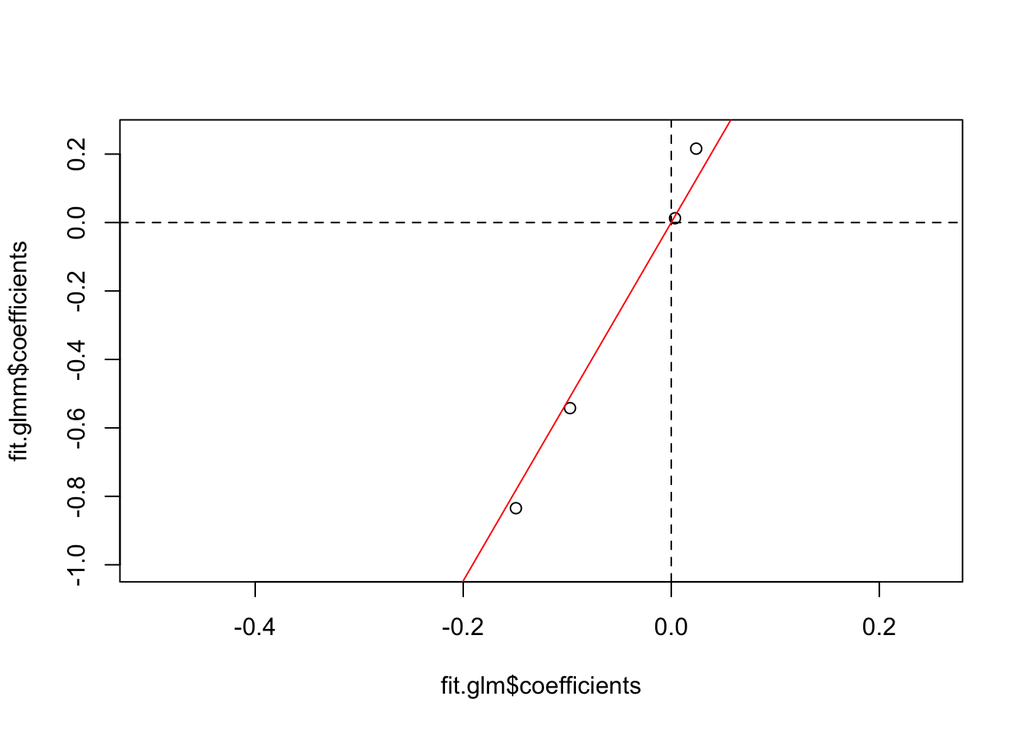

```r
plot(fit.glm$coefficients, fit.glmm$coefficients, xlim = c(-0.5, 0.25), ylim = c(-1, 0.25))
abline(v = 0, lty = 2)
abline(h = 0, lty = 2)
abline(a = 0, b = sqrt(1 + (fit.glmm$sigma/1.7)^2), col = "red")
```